# Example Report Template for a Data Analysis Project

Author

Kexin Cui & Rebecca Basta

The structure below is one possible setup for a report stemming from a data analysis project. It loosely follows the structure of a standard scientific manuscript. Adjust as needed. You don’t need to have exactly these sections, but the content covering those sections should be addressed.

This uses [HTML as output format](https://quarto.org/docs/output-formats/html-basics.html). See [the Quarto documentation](https://quarto.org/) for instructions on how to use other formats.

# 1 Summary/Abstract

This report demonstrates a simple, reproducible data analysis workflow, including data cleaning, exploratory analysis, and basic linear regression modeling. Newly added variables were incorporated to illustrate how extended data can be analyzed and reported within the READy framework.

# 2 Introduction

## 2.1 Description of data and data source

The dataset contains individual-level measurements of height, weight, and gender. To extend the original data, two additional variables were added. DailySteps is a numeric variable representing an individual’s average daily step count, and HairColor is a categorical variable describing self-reported hair color (e.g., Black, Brown, Blonde, Red). Descriptions of all variables, including the newly added ones, are provided in the Codebook sheet of the Excel file.

# 3 Methods

## 3.1 Data acquisition

The data used in this analysis were provided as an Excel file containing individual-level measurements of height, weight, and gender. Two additional variables were added for this exercise: a numerical variable representing average daily step count and a categorical variable representing hair color. All variables and their definitions are documented in the Codebook sheet of the Excel file.

## 3.2 Data import and cleaning

Data cleaning steps included removing or correcting implausible values (such as non-numeric height entries and impossible weight values), excluding observations with missing key variables, and converting categorical variables to factors. These steps were performed in a dedicated processing script to ensure reproducibility. The cleaned dataset was saved as an RDS file in the data/processed-data directory for downstream analysis.

## 3.3 Statistical analysis

Exploratory analyses were conducted using summary tables and visualizations, including histograms, boxplots, and scatterplots, to examine distributions and relationships among variables. For inferential analysis, simple linear regression models were fitted with height as the outcome variable. Models included height as a function of weight alone, height as a function of weight and gender, and height as a function of the newly added predictors. Model results were summarized into tidy tables and saved to the results/tables directory for inclusion in the report.

# 4 Results

## 4.1 Exploratory/Descriptive analysis

We first summarized the cleaned dataset using a descriptive summary table (Table 1 shows a summary of the data.). We also generated exploratory figures to visualize key distributions and relationships, including two figures that incorporate the newly added variables: a boxplot of height stratified by hair color (Figure 1) and a scatterplot of daily steps as a function of weight (Figure 2).

| skim_type | skim_variable | n_missing | complete_rate | factor.ordered | factor.n_unique | factor.top_counts | numeric.mean | numeric.sd | numeric.p0 | numeric.p25 | numeric.p50 | numeric.p75 | numeric.p100 | numeric.hist |
| --- | --- | --- | --- | --- | --- | --- | --- | --- | --- | --- | --- | --- | --- | --- |
| factor | Gender | 0 | 1 | FALSE | 3 | M: 4, F: 3, O: 2 | NA | NA | NA | NA | NA | NA | NA | NA |
| factor | HairColor | 0 | 1 | FALSE | 4 | Bla: 4, Bro: 3, Blo: 1, Red: 1 | NA | NA | NA | NA | NA | NA | NA | NA |
| numeric | Height | 0 | 1 | NA | NA | NA | 165.66667 | 15.97655 | 133 | 156 | 166 | 178 | 183 | ▂▁▃▃▇ |
| numeric | Weight | 0 | 1 | NA | NA | NA | 70.11111 | 21.24526 | 45 | 55 | 70 | 80 | 110 | ▇▂▃▂▂ |
| numeric | DailySteps | 0 | 1 | NA | NA | NA | 5712.22222 | 3067.01719 | 910 | 3000 | 7200 | 8200 | 9000 | ▃▂▂▂▇ |

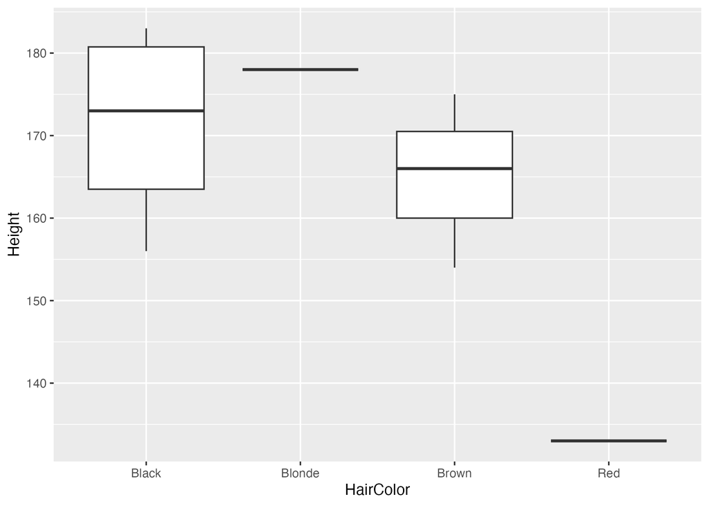

Figure 1: Boxplot of height stratified by hair color.

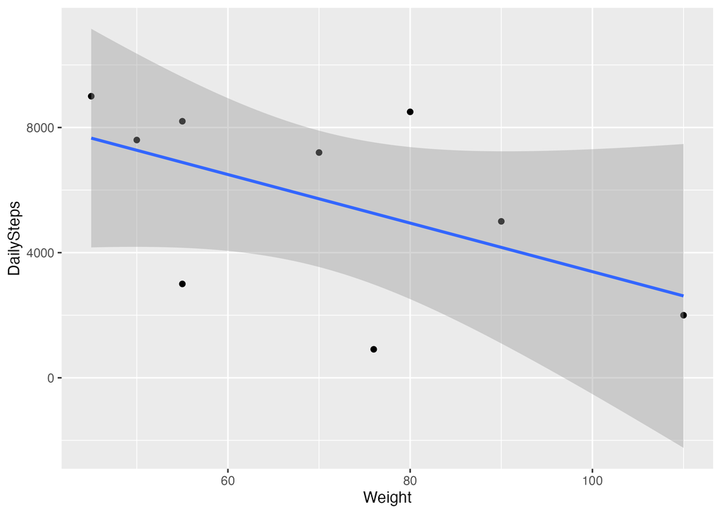

Figure 2: Scatterplot of daily steps as a function of weight.

## 4.2 Basic statistical analysis

Table 2: Linear regression results with height as the outcome and weight as the predictor.

| term | estimate | std.error | statistic | p.value |
| --- | --- | --- | --- | --- |
| (Intercept) | 149.6997661 | 19.7518528 | 7.5790240 | 0.0001285 |
| Weight | 0.2277371 | 0.2708841 | 0.8407177 | 0.4282860 |

Table 3: Linear regression results with height as the outcome and weight and gender as predictors.

| term | estimate | std.error | statistic | p.value |
| --- | --- | --- | --- | --- |
| (Intercept) | 149.2726967 | 23.3823360 | 6.3839942 | 0.0013962 |
| Weight | 0.2623972 | 0.3512436 | 0.7470519 | 0.4886517 |
| GenderM | -2.1244913 | 15.5488953 | -0.1366329 | 0.8966520 |
| GenderO | -4.7644739 | 19.0114155 | -0.2506112 | 0.8120871 |

## 4.3 Full analysis

Finally, a third linear regression model was fitted using the newly added variables—daily steps and hair color—as predictors of height. The results of this model are shown in Table 4.

Table 4: Linear regression results with height as the outcome and daily steps and hair color as predictors.

| term | estimate | std.error | statistic | p.value |
| --- | --- | --- | --- | --- |
| (Intercept) | 174.1897499 | 14.3129469 | 12.1700829 | 0.0002616 |
| DailySteps | -0.0004761 | 0.0020605 | -0.2310491 | 0.8286138 |
| HairColorBlonde | 4.2434764 | 18.2361059 | 0.2326964 | 0.8274189 |
| HairColorBrown | -6.5237419 | 10.0833954 | -0.6469787 | 0.5528999 |
| HairColorRed | -36.9050942 | 15.7717869 | -2.3399438 | 0.0793832 |

# 5 Discussion

## 5.1 Summary and Interpretation

This analysis explored relationships between height and several predictors using exploratory visualizations and simple linear regression models. Basic models examined associations with weight and gender, while a final model incorporated newly added variables. Together, these results illustrate how additional information can be integrated into a reproducible analysis workflow.

## 5.2 Strengths and Limitations

A strength of this analysis is the use of a fully scripted and reproducible workflow. Limitations include the small sample size and the exploratory nature of the analysis, which limits formal inference.

## 5.3 Conclusions

This exercise demonstrates a simple end-to-end data analysis using the READy workflow, from data cleaning to exploratory analysis, modeling, and reporting.

# 6 References